# Ford GoBike System Dataset exploration

## by Noel Khaemba

## Investigation Overview

> In this investigation I wanted to establish how long the average trip takes, whether the trip duration depend on if a user is a subscriber or customer and determine the relationship between the age of a bike user and the trip duration.

## Dataset Overview

> This dataset consists of information about individual rides made in a bike-sharing system covering the greater San Francisco Bay area.

> After data wrangling and removing outliers I remained with 174875 records which I used to to do the data analysis.

> the features of interest in the dataset are duration_sec, user_type, member_birth_year, member_gender, bike_share_for_all_trip

## Key Insights for Presentation

> The mean age of those who bike share across the different genders is lower than those who don't bike share.

> There are more subscribers with ages below 70 and with low bike durations compared to customers. Overall there are more subscribers than customers.

## (Visualization 1)

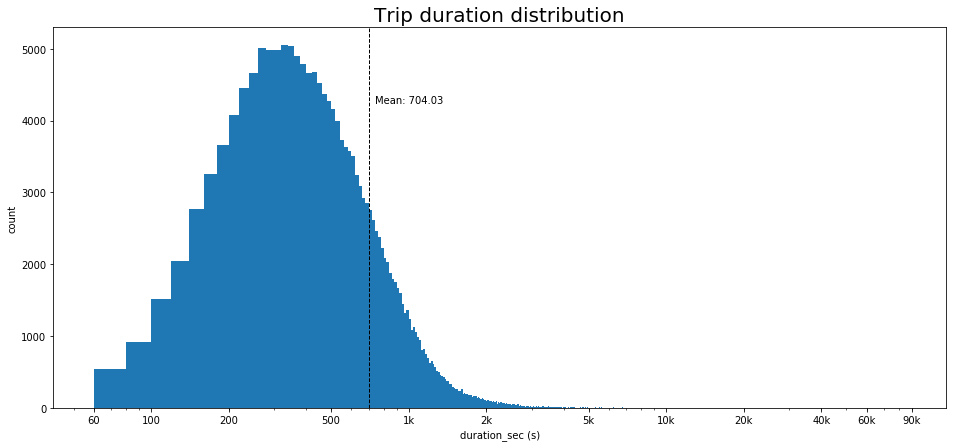

## (Visualization 2)

> The younger people between the ages of 20-50 years have more long duration bike rides than those above 60.

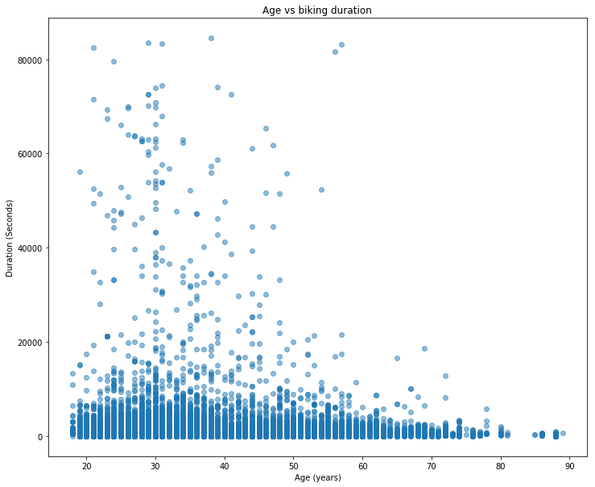

## (Visualization 3)

> The mean age of those who bike share across the different genders is lower than those who don't bike share.

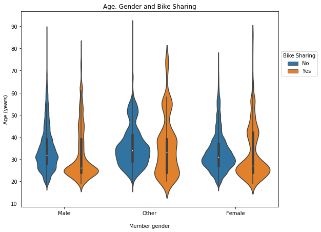

## (Visualization 4)

> There are more subscribers with ages below 70 and with low bike durations compared to customers. Overall there are more subscribers than customers.

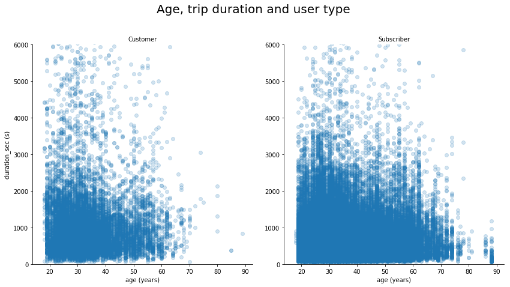